# Cleaning and Tidying data for Cyclist project

Fabiano Ju

2024-12-04

#### Installing and uploading packages needed:

```r
install.packages("tidyverse")
install.packages("skimr")
install.packages("janitor")
library(tidyverse)
```

```r
library(dplyr)
library(tidyr)
library(ggplot2)
library(readxl)
library(lubridate)
```

### Collecting the data for our analysis

In order to successfully analyze the data for the Cyclist project, we need our data clean and tidy. We have to data frame:

- Bike ride data of annual membership users and casual users of 2019_Q4
- Bike ride data of annual membership users and casual users of 2020_Q1

**Collecting the 2019_Q4 data**

```r
dt_19 <- read_csv("Divvy_Trips_2019_Q4.csv")
```

**Collecting the 2020_Q1 data**

```r
dt_20 <- read_csv("Divvy_Trips_2020_Q1.csv")
```

We have collected both 2019_Q4 and 2020_Q1 data. 2019_Q4 is named dt_19 and 2020_Q1 is named dt_20.

# Cleaning and Tidying data

Our goal is to merge both data frame and clean this data frame. This is the process we are going to take:

1. Merge the two data frame.
2. Clean data.
3. Make additional columns for ease of analysis.
4. Observe for outliers and filter them out if needed. (This step will be proceeded along the analysis phase).

## 1. Merge the two data frame

This is what we need to do in order merge the two data frame:

- Observe the each data frame. (Observe data type, data name, etc.)
- Unify column name.
- Merge the data.

### Observing the two data frame:

#### 2019_Q4 data

```r
head(dt_19) # This shows the first 6 rows of the data frame
```

| trip_id | start_time | end_time | bikeid | tripduration | from_station_id | from_station_name | to_station_id | to_station_name | usertype | gender | birthyear |
| --- | --- | --- | --- | --- | --- | --- | --- | --- | --- | --- | --- |
| 25223640 | 2019-10-01 00:01:39 | 2019-10-01 00:17:20 | 2215 | 940 | 20 | Sheffield Ave & Kingsbury St | 309 | Leavitt St & Armitage Ave | Subscriber | Male | 1987 |
| 25223641 | 2019-10-01 00:02:16 | 2019-10-01 00:06:34 | 6328 | 258 | 19 | Throop (Loomis) St & Taylor St | 241 | Morgan St & Polk St | Subscriber | Male | 1998 |
| 25223642 | 2019-10-01 00:04:32 | 2019-10-01 00:18:43 | 3003 | 850 | 84 | Milwaukee Ave & Grand Ave | 199 | Wabash Ave & Grand Ave | Subscriber | Female | 1991 |
| 25223643 | 2019-10-01 00:04:32 | 2019-10-01 00:43:43 | 3275 | 2350 | 313 | Lakeview Ave & Fullerton Pkwy | 290 | Kedzie Ave & Palmer Ct | Subscriber | Male | 1990 |
| 25223644 | 2019-10-01 00:04:34 | 2019-10-01 00:35:42 | 5294 | 1867 | 210 | Ashland Ave & Division St | 382 | Western Ave & Congress Pkwy | Subscriber | Male | 1987 |
| 25223645 | 2019-10-01 00:04:38 | 2019-10-01 00:10:51 | 1891 | 373 | 156 | Clark St & Wellington Ave | 226 | Racine Ave & Belmont Ave | Subscriber | Female | 1994 |

```r
str(dt_19) # This shows column names, data type of each column and some examples of data.
```

```
## spc_tbl_ [704,054 × 12] (S3: spec_tbl_df/tbl_df/tbl/data.frame)
##  $ trip_id          : num [1:704054] 25223640 25223641 25223642 25223643 25223644 ...
##  $ start_time       : POSIXct[1:704054], format: "2019-10-01 00:01:39" "2019-10-01 00:02:16" ...
##  $ end_time         : POSIXct[1:704054], format: "2019-10-01 00:17:20" "2019-10-01 00:06:34" ...
##  $ bikeid           : num [1:704054] 2215 6328 3003 3275 5294 ...
##  $ tripduration     : num [1:704054] 940 258 850 2350 1867 ...
##  $ from_station_id  : num [1:704054] 20 19 84 313 210 156 84 156 156 336 ...
##  $ from_station_name: chr [1:704054] "Sheffield Ave & Kingsbury St" "Throop (Loomis) St & Taylor St" "Milwaukee Ave & Grand Ave" "Lakeview Ave & Fullerton Pkwy" ...
##  $ to_station_id    : num [1:704054] 309 241 199 290 382 226 142 463 463 336 ...
##  $ to_station_name  : chr [1:704054] "Leavitt St & Armitage Ave" "Morgan St & Polk St" "Wabash Ave & Grand Ave" "Kedzie Ave & Palmer Ct" ...
##  $ usertype         : chr [1:704054] "Subscriber" "Subscriber" "Subscriber" "Subscriber" ...
##  $ gender           : chr [1:704054] "Male" "Male" "Female" "Male" ...
##  $ birthyear        : num [1:704054] 1987 1998 1991 1990 1987 ...
##  - attr(*, "spec")=
##   .. cols(
##   ..   trip_id = col_double(),
##   ..   start_time = col_datetime(format = ""),
##   ..   end_time = col_datetime(format = ""),
##   ..   bikeid = col_double(),
##   ..   tripduration = col_number(),
##   ..   from_station_id = col_double(),
##   ..   from_station_name = col_character(),
##   ..   to_station_id = col_double(),
##   ..   to_station_name = col_character(),
##   ..   usertype = col_character(),
##   ..   gender = col_character(),
##   ..   birthyear = col_double()
##   .. )
##  - attr(*, "problems")=<externalptr>
```

**We have some observations here:**

Data type should be changed: trip_id: character, bikeid: character, from_station_id: characte, to_station_id: character, birthyear: integer

```r
# Changing data type of dt_19 to it's appropriate data type:
dt_19 <- dt_19 %>%
  mutate(trip_id = as.character(trip_id),
         bikeid = as.character(bikeid),
         from_station_id = as.character(from_station_id),
         to_station_id = as.character(to_station_id),
         birthyear = as.integer(birthyear))
```

```r
#Checking if dt_19 has been changed appropriately.
str(dt_19)
```

```
## tibble [704,054 × 12] (S3: tbl_df/tbl/data.frame)
##  $ trip_id          : chr [1:704054] "25223640" "25223641" "25223642" "25223643" ...
##  $ start_time       : POSIXct[1:704054], format: "2019-10-01 00:01:39" "2019-10-01 00:02:16" ...
##  $ end_time         : POSIXct[1:704054], format: "2019-10-01 00:17:20" "2019-10-01 00:06:34" ...
##  $ bikeid           : chr [1:704054] "2215" "6328" "3003" "3275" ...
##  $ tripduration     : num [1:704054] 940 258 850 2350 1867 ...
##  $ from_station_id  : chr [1:704054] "20" "19" "84" "313" ...
##  $ from_station_name: chr [1:704054] "Sheffield Ave & Kingsbury St" "Throop (Loomis) St & Taylor St" "Milwaukee Ave & Grand Ave" "Lakeview Ave & Fullerton Pkwy" ...
##  $ to_station_id    : chr [1:704054] "309" "241" "199" "290" ...
##  $ to_station_name  : chr [1:704054] "Leavitt St & Armitage Ave" "Morgan St & Polk St" "Wabash Ave & Grand Ave" "Kedzie Ave & Palmer Ct" ...
##  $ usertype         : chr [1:704054] "Subscriber" "Subscriber" "Subscriber" "Subscriber" ...
##  $ gender           : chr [1:704054] "Male" "Male" "Female" "Male" ...
##  $ birthyear        : int [1:704054] 1987 1998 1991 1990 1987 1994 1991 1995 1993 NA ...
```

### 2020_Q1 data

```r
head(dt_20)
```

| ride_id | rideable_type | started_at | ended_at | start_station_name | start_station_id | end_station_name | end_station_id | start_lat | start_lng | end_lat | end_lng | member_casual |
| --- | --- | --- | --- | --- | --- | --- | --- | --- | --- | --- | --- | --- |
| EACB19130B0CDA4A | docked_bike | 2020-01-21 20:06:59 | 2020-01-21 20:14:30 | Western Ave & Leland Ave | 239 | Clark St & Leland Ave | 326 | 41.9665 | -87.6884 | 41.9671 | -87.6674 | member |
| 8FED874C809DC021 | docked_bike | 2020-01-30 14:22:39 | 2020-01-30 14:26:22 | Clark St & Montrose Ave | 234 | Southport Ave & Irving Park Rd | 318 | 41.9616 | -87.6660 | 41.9542 | -87.6644 | member |
| 789F3C21E472CA96 | docked_bike | 2020-01-09 19:29:26 | 2020-01-09 19:32:17 | Broadway & Belmont Ave | 296 | Wilton Ave & Belmont Ave | 117 | 41.9401 | -87.6455 | 41.9402 | -87.6530 | member |
| C9A388DAC6ABF313 | docked_bike | 2020-01-06 16:17:07 | 2020-01-06 16:25:56 | Clark St & Randolph St | 51 | Fairbanks Ct & Grand Ave | 24 | 41.8846 | -87.6319 | 41.8918 | -87.6206 | member |
| 943BC3CBECCFD662 | docked_bike | 2020-01-30 08:37:16 | 2020-01-30 08:42:48 | Clinton St & Lake St | 66 | Wells St & Hubbard St | 212 | 41.8856 | -87.6418 | 41.8899 | -87.6343 | member |
| 6D9C8A6938165C11 | docked_bike | 2020-01-10 12:33:05 | 2020-01-10 12:37:54 | Wells St & Hubbard St | 212 | Desplaines St & Randolph St | 96 | 41.8899 | -87.6343 | 41.8846 | -87.6446 | member |

```r
colnames(dt_20)
```

```
##  [1] "ride_id"            "rideable_type"      "started_at"
##  [4] "ended_at"           "start_station_name" "start_station_id"
##  [7] "end_station_name"   "end_station_id"     "start_lat"
## [10] "start_lng"          "end_lat"            "end_lng"
## [13] "member_casual"
```

```r
str(dt_20)
```

```
## spc_tbl_ [426,887 × 13] (S3: spec_tbl_df/tbl_df/tbl/data.frame)
##  $ ride_id           : chr [1:426887] "EACB19130B0CDA4A" "8FED874C809DC021" "789F3C21E472CA96" "C9A388DAC6ABF313" ...
##  $ rideable_type     : chr [1:426887] "docked_bike" "docked_bike" "docked_bike" "docked_bike" ...
##  $ started_at        : POSIXct[1:426887], format: "2020-01-21 20:06:59" "2020-01-30 14:22:39" ...
##  $ ended_at          : POSIXct[1:426887], format: "2020-01-21 20:14:30" "2020-01-30 14:26:22" ...
##  $ start_station_name: chr [1:426887] "Western Ave & Leland Ave" "Clark St & Montrose Ave" "Broadway & Belmont Ave" "Clark St & Randolph St" ...
##  $ start_station_id  : num [1:426887] 239 234 296 51 66 212 96 96 212 38 ...
##  $ end_station_name  : chr [1:426887] "Clark St & Leland Ave" "Southport Ave & Irving Park Rd" "Wilton Ave & Belmont Ave" "Fairbanks Ct & Grand Ave" ...
##  $ end_station_id    : num [1:426887] 326 318 117 24 212 96 212 212 96 100 ...
##  $ start_lat         : num [1:426887] 42 42 41.9 41.9 41.9 ...
##  $ start_lng         : num [1:426887] -87.7 -87.7 -87.6 -87.6 -87.6 ...
##  $ end_lat           : num [1:426887] 42 42 41.9 41.9 41.9 ...
##  $ end_lng           : num [1:426887] -87.7 -87.7 -87.7 -87.6 -87.6 ...
##  $ member_casual     : chr [1:426887] "member" "member" "member" "member" ...
##  - attr(*, "spec")=
##   .. cols(
##   ..   ride_id = col_character(),
##   ..   rideable_type = col_character(),
##   ..   started_at = col_datetime(format = ""),
##   ..   ended_at = col_datetime(format = ""),
##   ..   start_station_name = col_character(),
##   ..   start_station_id = col_double(),
##   ..   end_station_name = col_character(),
##   ..   end_station_id = col_double(),
##   ..   start_lat = col_double(),
##   ..   start_lng = col_double(),
##   ..   end_lat = col_double(),
##   ..   end_lng = col_double(),
##   ..   member_casual = col_character()
##   .. )
##  - attr(*, "problems")=<externalptr>
```

**Observation**: Column names from both data frame are different. Column name should be unified to that of dt_20.

- dt_20 dataframe’s datatype should be changed in some columns.
- dt_19 has data not included in dt_20, and dt_20 has information not included in dt_19.
- Discussion with stakeholders needed to decide what columns from dt_19 and dt_20 to keep.

**Changing data type of dt_20:**

```r
dt_20 <- dt_20 %>%
  mutate(start_station_id = as.character(start_station_id),
         end_station_id = as.character(end_station_id)
         )
```

```r
str(dt_20)
```

```
## tibble [426,887 × 13] (S3: tbl_df/tbl/data.frame)
##  $ ride_id           : chr [1:426887] "EACB19130B0CDA4A" "8FED874C809DC021" "789F3C21E472CA96" "C9A388DAC6ABF313" ...
##  $ rideable_type     : chr [1:426887] "docked_bike" "docked_bike" "docked_bike" "docked_bike" ...
##  $ started_at        : POSIXct[1:426887], format: "2020-01-21 20:06:59" "2020-01-30 14:22:39" ...
##  $ ended_at          : POSIXct[1:426887], format: "2020-01-21 20:14:30" "2020-01-30 14:26:22" ...
##  $ start_station_name: chr [1:426887] "Western Ave & Leland Ave" "Clark St & Montrose Ave" "Broadway & Belmont Ave" "Clark St & Randolph St" ...
##  $ start_station_id  : chr [1:426887] "239" "234" "296" "51" ...
##  $ end_station_name  : chr [1:426887] "Clark St & Leland Ave" "Southport Ave & Irving Park Rd" "Wilton Ave & Belmont Ave" "Fairbanks Ct & Grand Ave" ...
##  $ end_station_id    : chr [1:426887] "326" "318" "117" "24" ...
##  $ start_lat         : num [1:426887] 42 42 41.9 41.9 41.9 ...
##  $ start_lng         : num [1:426887] -87.7 -87.7 -87.6 -87.6 -87.6 ...
##  $ end_lat           : num [1:426887] 42 42 41.9 41.9 41.9 ...
##  $ end_lng           : num [1:426887] -87.7 -87.7 -87.7 -87.6 -87.6 ...
##  $ member_casual     : chr [1:426887] "member" "member" "member" "member" ...
```

**Aligning the column name to merge two dataframe:**

```r
colnames(dt_19)
```

```
##  [1] "trip_id"           "start_time"        "end_time"
##  [4] "bikeid"            "tripduration"      "from_station_id"
##  [7] "from_station_name" "to_station_id"     "to_station_name"
## [10] "usertype"          "gender"            "birthyear"
```

```r
colnames(dt_20)
```

```
##  [1] "ride_id"            "rideable_type"      "started_at"
##  [4] "ended_at"           "start_station_name" "start_station_id"
##  [7] "end_station_name"   "end_station_id"     "start_lat"
## [10] "start_lng"          "end_lat"            "end_lng"
## [13] "member_casual"
```

```r
str(dt_19)
```

```
## tibble [704,054 × 12] (S3: tbl_df/tbl/data.frame)
##  $ trip_id          : chr [1:704054] "25223640" "25223641" "25223642" "25223643" ...
##  $ start_time       : POSIXct[1:704054], format: "2019-10-01 00:01:39" "2019-10-01 00:02:16" ...
##  $ end_time         : POSIXct[1:704054], format: "2019-10-01 00:17:20" "2019-10-01 00:06:34" ...
##  $ bikeid           : chr [1:704054] "2215" "6328" "3003" "3275" ...
##  $ tripduration     : num [1:704054] 940 258 850 2350 1867 ...
##  $ from_station_id  : chr [1:704054] "20" "19" "84" "313" ...
##  $ from_station_name: chr [1:704054] "Sheffield Ave & Kingsbury St" "Throop (Loomis) St & Taylor St" "Milwaukee Ave & Grand Ave" "Lakeview Ave & Fullerton Pkwy" ...
##  $ to_station_id    : chr [1:704054] "309" "241" "199" "290" ...
##  $ to_station_name  : chr [1:704054] "Leavitt St & Armitage Ave" "Morgan St & Polk St" "Wabash Ave & Grand Ave" "Kedzie Ave & Palmer Ct" ...
##  $ usertype         : chr [1:704054] "Subscriber" "Subscriber" "Subscriber" "Subscriber" ...
##  $ gender           : chr [1:704054] "Male" "Male" "Female" "Male" ...
##  $ birthyear        : int [1:704054] 1987 1998 1991 1990 1987 1994 1991 1995 1993 NA ...
```

```r
str(dt_20)
```

```
## tibble [426,887 × 13] (S3: tbl_df/tbl/data.frame)
##  $ ride_id           : chr [1:426887] "EACB19130B0CDA4A" "8FED874C809DC021" "789F3C21E472CA96" "C9A388DAC6ABF313" ...
##  $ rideable_type     : chr [1:426887] "docked_bike" "docked_bike" "docked_bike" "docked_bike" ...
##  $ started_at        : POSIXct[1:426887], format: "2020-01-21 20:06:59" "2020-01-30 14:22:39" ...
##  $ ended_at          : POSIXct[1:426887], format: "2020-01-21 20:14:30" "2020-01-30 14:26:22" ...
##  $ start_station_name: chr [1:426887] "Western Ave & Leland Ave" "Clark St & Montrose Ave" "Broadway & Belmont Ave" "Clark St & Randolph St" ...
##  $ start_station_id  : chr [1:426887] "239" "234" "296" "51" ...
##  $ end_station_name  : chr [1:426887] "Clark St & Leland Ave" "Southport Ave & Irving Park Rd" "Wilton Ave & Belmont Ave" "Fairbanks Ct & Grand Ave" ...
##  $ end_station_id    : chr [1:426887] "326" "318" "117" "24" ...
##  $ start_lat         : num [1:426887] 42 42 41.9 41.9 41.9 ...
##  $ start_lng         : num [1:426887] -87.7 -87.7 -87.6 -87.6 -87.6 ...
##  $ end_lat           : num [1:426887] 42 42 41.9 41.9 41.9 ...
##  $ end_lng           : num [1:426887] -87.7 -87.7 -87.7 -87.6 -87.6 ...
##  $ member_casual     : chr [1:426887] "member" "member" "member" "member" ...
```

```r
dt_19 <- dt_19 %>%
  rename(ride_id = trip_id,
         started_at = start_time,
         ended_at = end_time,
         start_station_id = from_station_id,
         start_station_name = from_station_name,
         end_station_id = to_station_id,
         end_station_name = to_station_name,
         member_casual = usertype)
```

**Checking if both column names have been aligned:**

```r
colnames(dt_19)
```

```
##  [1] "ride_id"            "started_at"         "ended_at"
##  [4] "bikeid"             "tripduration"       "start_station_id"
##  [7] "start_station_name" "end_station_id"     "end_station_name"
## [10] "member_casual"      "gender"             "birthyear"
```

```r
colnames(dt_20)
```

```
##  [1] "ride_id"            "rideable_type"      "started_at"
##  [4] "ended_at"           "start_station_name" "start_station_id"
##  [7] "end_station_name"   "end_station_id"     "start_lat"
## [10] "start_lng"          "end_lat"            "end_lng"
## [13] "member_casual"
```

**Eliminating columns not needed for the data analysis** - After discussing with team members and stakeholder, these are the columns decided to keep:

**Data column to keep in dt_19:** - ride_id, started_at, ended_at, start_station_id, start_station_name, end_station_id, end_station_name, member_casual, gender, birthyear.

**Data column to eliminate in dt_19:** bikeid: Doesn’t lead to analysis needed. tripduration: It’s better to make a new column of tripduration after merging two dataframe.

**Data column to keep in dt_20:** ride_id, started_at, ended_at, start_station_name, start_station_id, end_station_name, end_station_id, member_casual.

**Data column to eliminate in dt_20:** rideable_type: Doesn’t lead to analysis needed. start_lat: Doesn’t lead to analysis needed. start_lng: Doesn’t lead to analysis needed. end_lat: Doesn’t lead to analysis needed. end_lng: Doesn’t lead to analysis needed.

**Eliminating columns not needed:**

```r
dt_19 <- dt_19 %>%
  select(-bikeid, -tripduration)
```

```r
dt_20 <- dt_20 %>%
  select(-rideable_type, -start_lat, -start_lng, -end_lat, -end_lng)
```

```r
colnames(dt_19)
```

```
##  [1] "ride_id"            "started_at"         "ended_at"
##  [4] "start_station_id"   "start_station_name" "end_station_id"
##  [7] "end_station_name"   "member_casual"      "gender"
## [10] "birthyear"
```

```r
colnames(dt_20)
```

```
## [1] "ride_id"            "started_at"         "ended_at"
## [4] "start_station_name" "start_station_id"   "end_station_name"
## [7] "end_station_id"     "member_casual"
```

**Merging two data:**

```r
dt <- bind_rows(dt_19, dt_20)
```

```r
str(dt)
```

```
## tibble [1,130,941 × 10] (S3: tbl_df/tbl/data.frame)
##  $ ride_id           : chr [1:1130941] "25223640" "25223641" "25223642" "25223643" ...
##  $ started_at        : POSIXct[1:1130941], format: "2019-10-01 00:01:39" "2019-10-01 00:02:16" ...
##  $ ended_at          : POSIXct[1:1130941], format: "2019-10-01 00:17:20" "2019-10-01 00:06:34" ...
##  $ start_station_id  : chr [1:1130941] "20" "19" "84" "313" ...
##  $ start_station_name: chr [1:1130941] "Sheffield Ave & Kingsbury St" "Throop (Loomis) St & Taylor St" "Milwaukee Ave & Grand Ave" "Lakeview Ave & Fullerton Pkwy" ...
##  $ end_station_id    : chr [1:1130941] "309" "241" "199" "290" ...
##  $ end_station_name  : chr [1:1130941] "Leavitt St & Armitage Ave" "Morgan St & Polk St" "Wabash Ave & Grand Ave" "Kedzie Ave & Palmer Ct" ...
##  $ member_casual     : chr [1:1130941] "Subscriber" "Subscriber" "Subscriber" "Subscriber" ...
##  $ gender            : chr [1:1130941] "Male" "Male" "Female" "Male" ...
##  $ birthyear         : int [1:1130941] 1987 1998 1991 1990 1987 1994 1991 1995 1993 NA ...
```

## 2. Cleaning and tidying the merged data, dt

**These are the things needed for a clean data**

- Check for null values, delete these rows if needed.
- Check for duplicates, delete if needed.
- Check for typos or inconsistent values, and delete them if needed.

### **Checking for null values, deleting them if needed:**

**Checking for null values.**

```r
dt %>%
  summarise(across(everything(), ~ sum(is.na(.))))
```

| ride_id | started_at | ended_at | start_station_id | start_station_name | end_station_id | end_station_name | member_casual | gender | birthyear |
| --- | --- | --- | --- | --- | --- | --- | --- | --- | --- |
| 0 | 0 | 0 | 0 | 0 | 1 | 1 | 0 | 493478 | 488568 |

Observation: - end_station_id and end_station_name has a missing value. This is the missing row:

```r
# Missing rows of dt
dt %>%
  filter(is.na(end_station_id))
```

| ride_id | started_at | ended_at | start_station_id | start_station_name | end_station_id | end_station_name | member_casual | gender | birthyear |
| --- | --- | --- | --- | --- | --- | --- | --- | --- | --- |
| 157EAA4C4A3C8D36 | 2020-03-16 11:23:36 | 2020-03-16 11:23:24 | 675 | HQ QR | NA | NA | casual | NA | NA |

Deleting this row:

```r
dt <- dt %>%
  filter(if_all(c(end_station_id), ~ !is.na(.)))
```

**Checking for duplicates.**

```r
dt %>%
  group_by(across(everything())) %>%
  filter(n() > 1) %>%
  ungroup()
```

| ride_id | started_at | ended_at | start_station_id | start_station_name | end_station_id | end_station_name | member_casual | gender | birthyear |
| --- | --- | --- | --- | --- | --- | --- | --- | --- | --- |

We can see there are no duplicate rows.

**Checking for typos and inconsistent values.** Checking inconsistencies on column member_casual:

```r
dt %>%
  select(member_casual) %>%
  distinct()
```

| member_casual |
| --- |
| Subscriber |
| Customer |
| member |
| casual |

**Observation** - Subscriber should be changed to member. - Customer should be changed to casual.

```r
#Changing Subscriber to member and Customer to casual:
dt <- dt %>%
  mutate(member_casual = case_when(member_casual == "Subscriber" ~ "member",
                                   member_casual == "Customer" ~ "casual",
                                   TRUE ~ member_casual
                                   ))
```

```r
#Checking if data name has been changed correctly.
dt %>%
  select(member_casual) %>%
  distinct()
```

| member_casual |
| --- |
| member |
| casual |

**Checking for inconsistent values on column gender**

```r
dt %>%
  select(gender) %>%
  group_by(gender) %>%
  summarise(count = n())
```

| gender | count |
| --- | --- |
| Female | 151004 |
| Male | 486459 |
| NA | 493477 |

No insconsistent values in gender column.

**Checking for inconsistent values on column birthyear**

```r
dt %>%
  select(birthyear) %>%
  drop_na() %>%
  summarise(oldest = min(birthyear),
            youngest = max(birthyear))
```

| oldest | youngest |
| --- | --- |
| 1899 | 2003 |

## 3. Organizing and adding column for a better data analysis.

```r
colnames(dt)
```

```
##  [1] "ride_id"            "started_at"         "ended_at"
##  [4] "start_station_id"   "start_station_name" "end_station_id"
##  [7] "end_station_name"   "member_casual"      "gender"
## [10] "birthyear"
```

**Observations:** - A separate column for year, month, day, and weekday needed for a better and easier analysis. - Additional column indication trip duration needed.

**Making additional column for year, month and day:**

```r
dt <- dt %>%
  mutate(year = year(started_at),
         month = month(started_at),
         day = day(started_at))
```

**Making additional column for weekday:**

```r
dt <- dt %>%
  mutate(weekday = wday(started_at, label = TRUE, abbr = FALSE))
```

Checking if additional columns were made:

```r
head(dt)
```

| ride_id | started_at | ended_at | start_station_id | start_station_name | end_station_id | end_station_name | member_casual | gender | birthyear | year | month | day | weekday |
| --- | --- | --- | --- | --- | --- | --- | --- | --- | --- | --- | --- | --- | --- |
| 25223640 | 2019-10-01 00:01:39 | 2019-10-01 00:17:20 | 20 | Sheffield Ave & Kingsbury St | 309 | Leavitt St & Armitage Ave | member | Male | 1987 | 2019 | 10 | 1 | Tuesday |
| 25223641 | 2019-10-01 00:02:16 | 2019-10-01 00:06:34 | 19 | Throop (Loomis) St & Taylor St | 241 | Morgan St & Polk St | member | Male | 1998 | 2019 | 10 | 1 | Tuesday |
| 25223642 | 2019-10-01 00:04:32 | 2019-10-01 00:18:43 | 84 | Milwaukee Ave & Grand Ave | 199 | Wabash Ave & Grand Ave | member | Female | 1991 | 2019 | 10 | 1 | Tuesday |
| 25223643 | 2019-10-01 00:04:32 | 2019-10-01 00:43:43 | 313 | Lakeview Ave & Fullerton Pkwy | 290 | Kedzie Ave & Palmer Ct | member | Male | 1990 | 2019 | 10 | 1 | Tuesday |
| 25223644 | 2019-10-01 00:04:34 | 2019-10-01 00:35:42 | 210 | Ashland Ave & Division St | 382 | Western Ave & Congress Pkwy | member | Male | 1987 | 2019 | 10 | 1 | Tuesday |
| 25223645 | 2019-10-01 00:04:38 | 2019-10-01 00:10:51 | 156 | Clark St & Wellington Ave | 226 | Racine Ave & Belmont Ave | member | Female | 1994 | 2019 | 10 | 1 | Tuesday |

**Making trip duration column**

```r
class(dt$started_at)
```

```
## [1] "POSIXct" "POSIXt"
```

```r
class(dt$ended_at)
```

```
## [1] "POSIXct" "POSIXt"
```

```r
dt<- dt %>%
  mutate(trip_duration = ended_at - started_at)
```

```r
dt %>%
  select(trip_duration) %>%
  slice_head(n = 10)
```

| trip_duration |
| --- |
| 941 secs |
| 258 secs |
| 851 secs |
| 2351 secs |
| 1868 secs |
| 373 secs |
| 1073 secs |
| 1459 secs |
| 1438 secs |
| 8306 secs |

We have trip_duration column in seconds. But if we need an additional column with trip_duration in minutes and hours, it will be easy for data analysis also.

```r
dt <- dt %>%
  mutate(trip_minutes = round(trip_duration / 60, 2),
         trip_hours = round(trip_duration / 3600, 2)
         )
```

```r
str(dt)
```

```
## tibble [1,130,940 × 17] (S3: tbl_df/tbl/data.frame)
##  $ ride_id           : chr [1:1130940] "25223640" "25223641" "25223642" "25223643" ...
##  $ started_at        : POSIXct[1:1130940], format: "2019-10-01 00:01:39" "2019-10-01 00:02:16" ...
##  $ ended_at          : POSIXct[1:1130940], format: "2019-10-01 00:17:20" "2019-10-01 00:06:34" ...
##  $ start_station_id  : chr [1:1130940] "20" "19" "84" "313" ...
##  $ start_station_name: chr [1:1130940] "Sheffield Ave & Kingsbury St" "Throop (Loomis) St & Taylor St" "Milwaukee Ave & Grand Ave" "Lakeview Ave & Fullerton Pkwy" ...
##  $ end_station_id    : chr [1:1130940] "309" "241" "199" "290" ...
##  $ end_station_name  : chr [1:1130940] "Leavitt St & Armitage Ave" "Morgan St & Polk St" "Wabash Ave & Grand Ave" "Kedzie Ave & Palmer Ct" ...
##  $ member_casual     : chr [1:1130940] "member" "member" "member" "member" ...
##  $ gender            : chr [1:1130940] "Male" "Male" "Female" "Male" ...
##  $ birthyear         : int [1:1130940] 1987 1998 1991 1990 1987 1994 1991 1995 1993 NA ...
##  $ year              : num [1:1130940] 2019 2019 2019 2019 2019 ...
##  $ month             : num [1:1130940] 10 10 10 10 10 10 10 10 10 10 ...
##  $ day               : int [1:1130940] 1 1 1 1 1 1 1 1 1 1 ...
##  $ weekday           : Ord.factor w/ 7 levels "Sunday"<"Monday"<..: 3 3 3 3 3 3 3 3 3 3 ...
##  $ trip_duration     : 'difftime' num [1:1130940] 941 258 851 2351 ...
##   ..- attr(*, "units")= chr "secs"
##  $ trip_minutes      : 'difftime' num [1:1130940] 15.68 4.3 14.18 39.18 ...
##   ..- attr(*, "units")= chr "secs"
##  $ trip_hours        : 'difftime' num [1:1130940] 0.26 0.07 0.24 0.65 ...
##   ..- attr(*, "units")= chr "secs"
```

## 4. Find out outliers and filter them out.

###Trip duration

```r
dt %>%
  group_by(member_casual) %>%
  summarise(avg_trip_duration = mean(trip_duration),
            max_trip_duration = max(trip_duration),
            min_trip_duration = min(trip_duration),
            sd_trip_duration = sd(trip_duration, na.rm = FALSE)
  )
```

| member_casual | avg_trip_duration | max_trip_duration | min_trip_duration | sd_trip_duration |
| --- | --- | --- | --- | --- |
| casual | 4317.2630 secs | 9387024 secs | -2897 secs | 77905.57 |
| member | 753.9996 secs | 5627611 secs | -3382 secs | 11753.23 |

**Observations** - There are negative values in trip duration. These cases are outliers and should be filtered out - Compared to the average trip duration, the longest single trip duration is way longer. - These long trips leads to huge standard deviation, and also hindering us from getting insights. - These long trips should also be filtred out, to get insight from average cases.

**Filtering out negative trip durations**

```r
dt <- dt %>%
  filter(trip_duration >= 0)
```

**Filtering out extremely long rides** - To see which trips are extremely long, data visualization helps in that process:

```
## Defaulting to continuous.
```

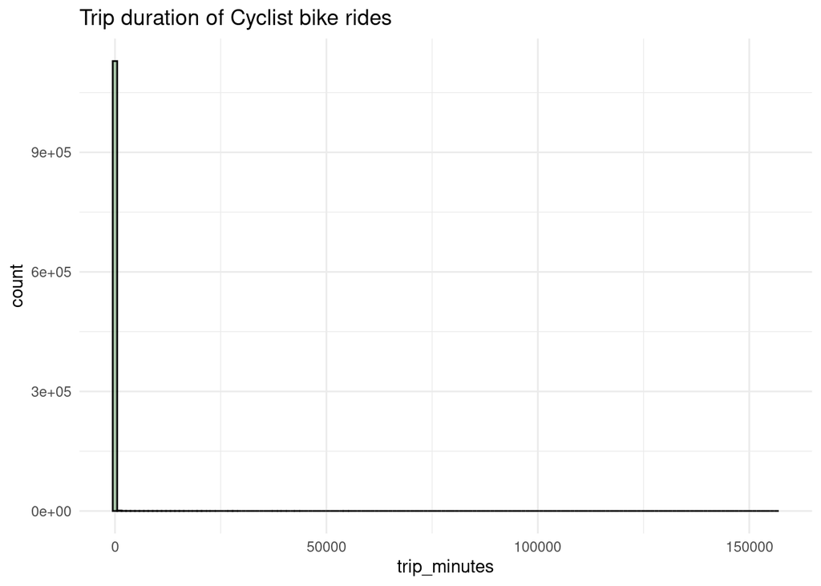

```r
ggplot(data = dt) +
  geom_histogram(mapping = aes(x = trip_minutes), bins = 150,
                 fill = "darkgreen", alpha = 0.3, color = "black") +
  labs(title = "Trip duration of Cyclist bike rides") + theme_minimal()
```

There are only a single bar because most cases are in that bar, on some outliers have huge times. We need to filter out these outliers:

```
## Defaulting to continuous.
```

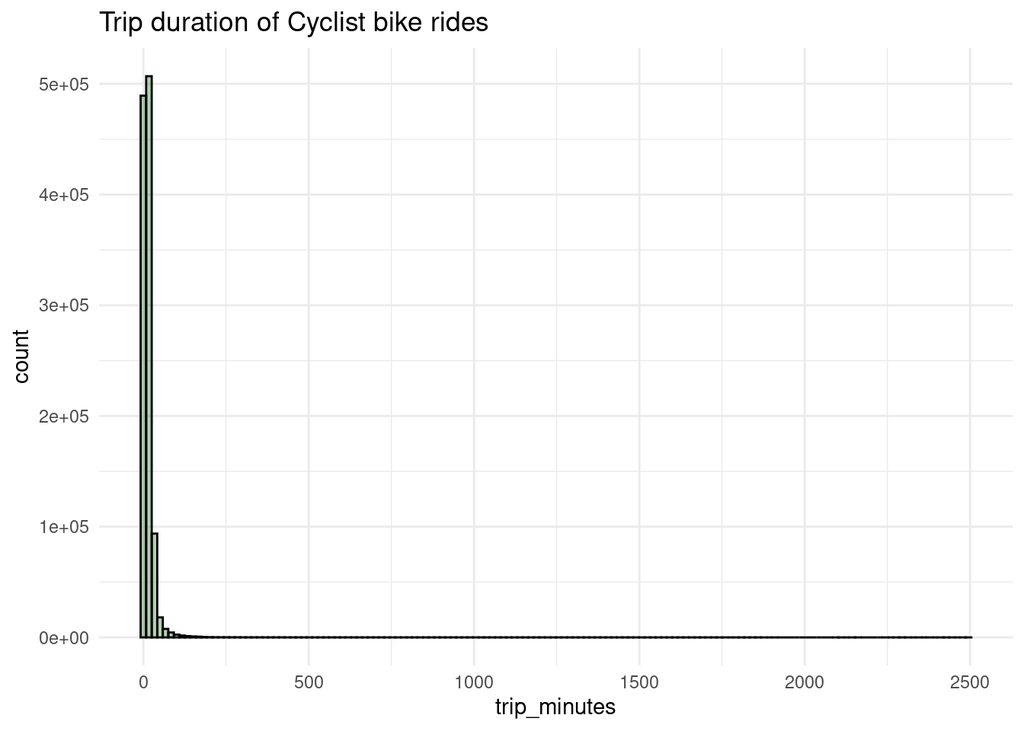

```r
ggplot(data = dt %>% filter(trip_minutes < 2500)) +
  geom_histogram(mapping = aes(x = trip_minutes), bins = 150,
                 fill = "darkgreen", alpha = 0.3, color = "black") +
  labs(title = "Trip duration of Cyclist bike rides") + theme_minimal()
```

We can see that even in these case, there are many outliers. But with this graph, we know we can filter out trips that are longer than 250 minutes.

```
## Defaulting to continuous.
```

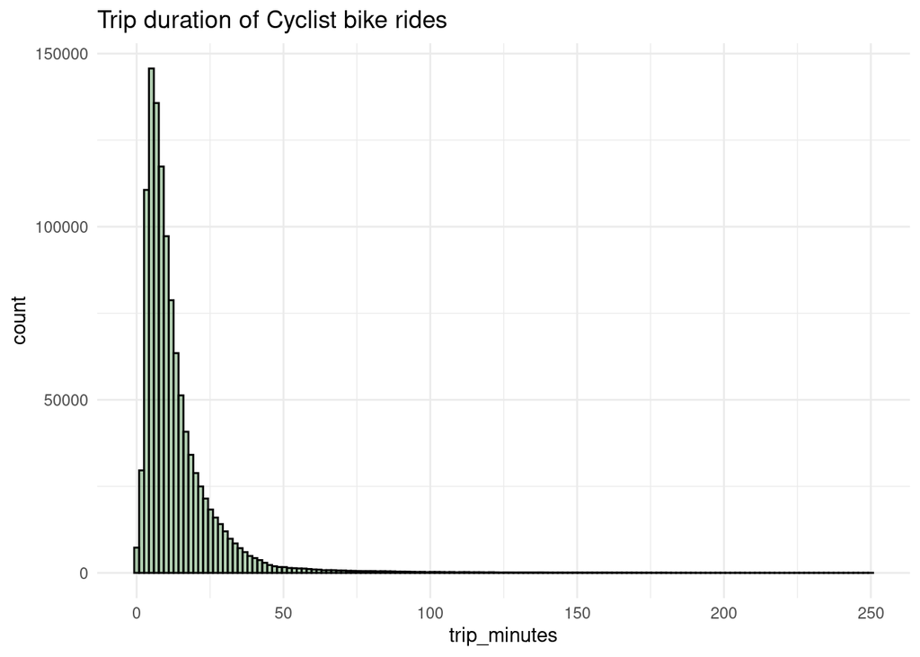

```r
ggplot(data = dt %>% filter(trip_minutes < 250)) +
  geom_histogram(mapping = aes(x = trip_minutes), bins = 150,
                 fill = "darkgreen", alpha = 0.3, color = "black") +
  labs(title = "Trip duration of Cyclist bike rides") + theme_minimal()
```

Let’s filter out trips longer than 125 minutes:

```
## Defaulting to continuous.
```

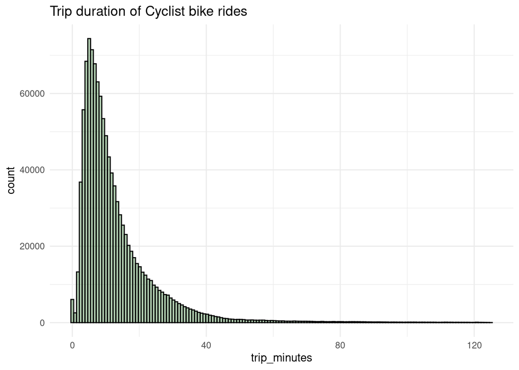

```r
ggplot(data = dt %>% filter(trip_minutes < 125)) +
  geom_histogram(mapping = aes(x = trip_minutes), bins = 150,
                 fill = "darkgreen", alpha = 0.3, color = "black") +
  labs(title = "Trip duration of Cyclist bike rides") + theme_minimal()
```

We now can clearly see the trip duration trend.

```r
dt <- dt %>%
  filter(trip_minutes <= 125)
```

**We have our data ready for the analysis!**

```r
str(dt)
```

```
## tibble [1,124,379 × 17] (S3: tbl_df/tbl/data.frame)
##  $ ride_id           : chr [1:1124379] "25223640" "25223641" "25223642" "25223643" ...
##  $ started_at        : POSIXct[1:1124379], format: "2019-10-01 00:01:39" "2019-10-01 00:02:16" ...
##  $ ended_at          : POSIXct[1:1124379], format: "2019-10-01 00:17:20" "2019-10-01 00:06:34" ...
##  $ start_station_id  : chr [1:1124379] "20" "19" "84" "313" ...
##  $ start_station_name: chr [1:1124379] "Sheffield Ave & Kingsbury St" "Throop (Loomis) St & Taylor St" "Milwaukee Ave & Grand Ave" "Lakeview Ave & Fullerton Pkwy" ...
##  $ end_station_id    : chr [1:1124379] "309" "241" "199" "290" ...
##  $ end_station_name  : chr [1:1124379] "Leavitt St & Armitage Ave" "Morgan St & Polk St" "Wabash Ave & Grand Ave" "Kedzie Ave & Palmer Ct" ...
##  $ member_casual     : chr [1:1124379] "member" "member" "member" "member" ...
##  $ gender            : chr [1:1124379] "Male" "Male" "Female" "Male" ...
##  $ birthyear         : int [1:1124379] 1987 1998 1991 1990 1987 1994 1991 1995 1993 1977 ...
##  $ year              : num [1:1124379] 2019 2019 2019 2019 2019 ...
##  $ month             : num [1:1124379] 10 10 10 10 10 10 10 10 10 10 ...
##  $ day               : int [1:1124379] 1 1 1 1 1 1 1 1 1 1 ...
##  $ weekday           : Ord.factor w/ 7 levels "Sunday"<"Monday"<..: 3 3 3 3 3 3 3 3 3 3 ...
##  $ trip_duration     : 'difftime' num [1:1124379] 941 258 851 2351 ...
##   ..- attr(*, "units")= chr "secs"
##  $ trip_minutes      : 'difftime' num [1:1124379] 15.68 4.3 14.18 39.18 ...
##   ..- attr(*, "units")= chr "secs"
##  $ trip_hours        : 'difftime' num [1:1124379] 0.26 0.07 0.24 0.65 ...
##   ..- attr(*, "units")= chr "secs"
```